# Simulate Social Network Intervention to Adopt AI Chatbots for Increasing Physical Activity

For PHS 7045

Lingyi Fu

## Background

#### Adopt AI Chatbot for Increasing Physical Activity

- Artificial intelligence (AI)-driven Chatbots (AI chatbots), developed using natural language processing techniques, are capable of conversing with humans in a natural language format.
- AI chatbots have been used to increase physical activity recently.
- The adoption of an AI Chatbot is a critical factor that influences the efficacy of using an AI chatbot to increase physical activity (PA). A high adoption can promote a high level of PA.

## Diffusion of Innovation Theory

- Diffusion of Innovation (DOI) theory is a social science theory that explains how new ideas, products, or behaviors spread through a population over time.

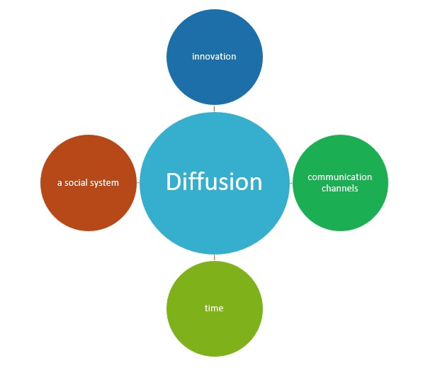

## Diffusion of Innovation Theory

- This theory emphasizes the effect of the **social networks** on the adoption of an innovation.

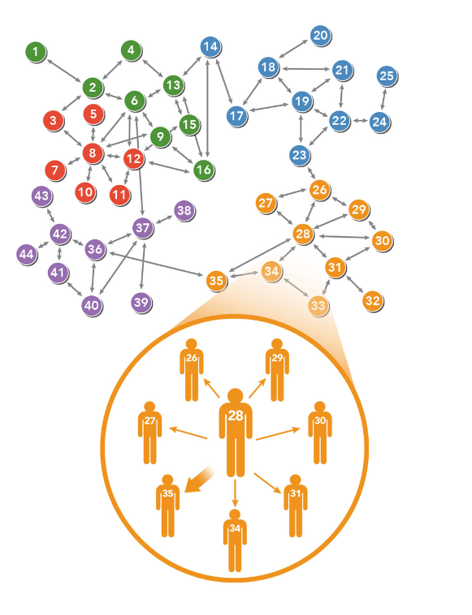

  https://researchfeatures.com/diffusion-innovations-within-social-networks/

## Diffusion of Innovation Theory

- It also describes five stages of the population adopting an innovation, including innovators, early adopters, early majority, late majority, and laggards.

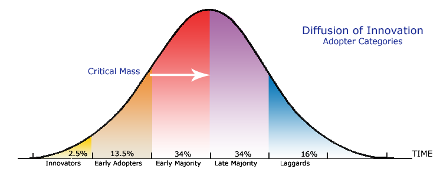

## Project Aim

This project aims to simulate a social network intervention to understand how the social network affects an individual’s adoption of an AI chatbot, thus increasing their physical activity. There are two main steps:

- **Step 1. Simulate the Diffusion Process of Adopting an AI Chatbot Within the Social Network.**
- Step 2. Explore the percentage of people meeting the US PA guidelines in different stages of adopters and non-adopters.

## Solution Plan

- **Step 1-1. Simulate correlation matrix**

  Simulate a correlation matrix among 25 nodes with the correlation coefficent ranging from -1 to 1.

  ```r
  cormatrix <- matrix(runif(num_nodes^2, min = -1, max = 1), num_nodes)
  ```

- **Step 1-2. Initialize network structure based on the adjacency matrix**

  Create a network graph based on an adjacency matrix derived from the correlation matrix.

  ```r
  cormatrix[lower.tri(cormatrix)] <- t(cormatrix)[lower.tri(cormatrix)] #Make symmetric
  diag(cormatrix) <- 0 #set diag as 0

  threshold <- 0.7 # Only keep edges with a correlation > 0.7 based on the correlation cut-off

  adj_matrix <- abs(cormatrix) > threshold
  adj_matrix[upper.tri(adj_matrix)] <- FALSE

  #initial weights
  initial_graph <- graph_from_adjacency_matrix(adj_matrix, mode = "undirected", weighted = TRUE)
  edge_weights <- cormatrix[adj_matrix]

  #define the parameters of the network layout
  fixed_layout <- layout_with_graphopt(initial_graph)
  E(initial_graph)$weight <- edge_weights
  E(initial_graph)$width <- abs(E(initial_graph)$weight) * 4
  E(initial_graph)$color <- ifelse(E(initial_graph)$weight > 0,  "#000080", "#B22222")
  V(initial_graph)$size  <- 20
  V(initial_graph)$color <- "gray"
  V(initial_graph)$label.color <- "black"
  ```

- **Step 1-3. Calculate the centrality of each node**

  Based on the simulated network, the centrality of each node in the network was calculated. The strength metric was used to determine the centrality, which represents the sum of weights that a given individual associate with other individuals.

  ```r
  node_strength <- strength(initial_graph, vids = V(initial_graph), mode = "all", weights = E(initial_graph)$weight)
  ```

- **Step 1-4. Simulate diffusion process**

  Lastly, the diffusion process was simulated. Based on DOI theory, there are five stages. For each stage, different individuals were assigned to adopt the technology based on two types of criteria.
  - **Criteria 1:** The innovators were determined 2.5% highest centrality nodes.
  - **Criteria 2:** Early adopters, early majority, late majority, and laggards were determined based on the two sub-criteria:
    - These nodes were connected with the nodes at the prior stage;
    - These nodes ranked in the top percentage of the adopter category for weight centrality (e.g., 13.5% for early adopters).

```r
n_innovators <- round(num_nodes*0.025)
n_early_adopters <- round(num_nodes*0.135)
n_early_majority <- round(num_nodes*0.34)
n_late_majority <- round(num_nodes*0.34)
n_laggards <-  round(num_nodes*0.16)

numer_phases <- c(n_innovators, n_early_adopters,n_early_majority, n_late_majority, n_laggards)

simulate_diffusion <- function(initial_graph, total_phase, node_strength, numer_phases, node_colors, phase_colors){
  total_phase <- total_phase
  top_indices <- NaN
  used_nodes <- list()
  adoption_history <- list()

  for (i in 1:total_phase){
    num_phase <- numer_phases[i]

    if (i == 1){
      top_indices <- order(node_strength, decreasing = TRUE)[1:num_phase]

    }else{
      connected_nodes <- unique(unlist(lapply(top_indices, function(x) {
        c(neighbors(initial_graph, x, mode = "all"))
      })))

      #print(connected_nodes)
      #remove the used nodes
      if (any((used_nodes) %in% connected_nodes)){
        connected_nodes <- setdiff(connected_nodes, used_nodes)
      }else{
        connected_nodes <- connected_nodes
      }
      weights_connected_nodes <- node_strength[connected_nodes]
      medium <- order(weights_connected_nodes, decreasing = TRUE)[1:num_phase]
      top_indices <-connected_nodes[medium]
      #print(top_indices)
    }
    # Save the adoption picture
    top_indices <- top_indices
    used_nodes <- unlist(append(used_nodes, top_indices))
    adoption_history[i] <- list(top_indices)
  }

  return(adoption_history)
}

total_phase <- 5
adoption_history <- simulate_diffusion(initial_graph, total_phase, node_strength, numer_phases, node_colors, phase_colors)
adoption_history
```

[output not shown]

## Preliminary Result

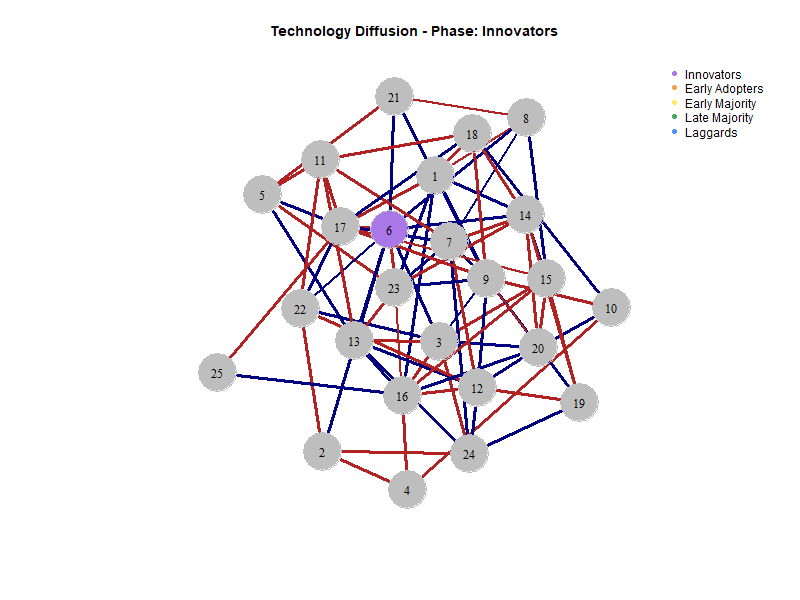

## Next Step

- Determine an adoption rate that this approach can achieve rather than presetting the adoption rate as 100%.
- Compare the percentage of individuals meeting the PA guidelines across different stages of adopters and non-adopters.